# 0609_Time series final report

### 柒、預測

1. 24-steps ahead predictions and confidence intervals

```r
library(forecast)
forcastm121 <- forecast(mfit121, level=c(95), h=2*12)
forcast42 <- forecast(fit42, level=c(95), h=2*12)
forcastm71 <- forecast(mfit71, level=c(95), h=2*12)
forcastm121
```

```
##          Point Forecast    Lo 95    Hi 95
## Jan 2016       5.498251 5.496286 5.500217
## Feb 2016       5.501523 5.498567 5.504478
## Mar 2016       5.505087 5.501254 5.508920
## Apr 2016       5.507553 5.502884 5.512222
## May 2016       5.509247 5.503759 5.514735
## Jun 2016       5.510147 5.503846 5.516447
## Jul 2016       5.510544 5.503432 5.517656
## Aug 2016       5.511640 5.503716 5.519564
## Sep 2016       5.514164 5.505425 5.522903
## Oct 2016       5.516492 5.506934 5.526049
## Nov 2016       5.516597 5.506218 5.526976
## Dec 2016       5.515380 5.504177 5.526583
## Jan 2017       5.517301 5.504975 5.529628
## Feb 2017       5.520510 5.507055 5.533966
## Mar 2017       5.524142 5.509552 5.538731
## Apr 2017       5.526786 5.511057 5.542514
## May 2017       5.528419 5.511548 5.545291
## Jun 2017       5.529351 5.511333 5.547370
## Jul 2017       5.529749 5.510581 5.548917
## Aug 2017       5.530736 5.510416 5.551056
## Sep 2017       5.533294 5.511821 5.554768
## Oct 2017       5.535659 5.513031 5.558287
## Nov 2017       5.535842 5.512059 5.559625
## Dec 2017       5.534708 5.509770 5.559646
```

```r
forcast42
```

```
##     Point Forecast       Lo 95        Hi 95
## 313    -0.02923918 -0.03113519 -0.027343163
## 314    -0.02748897 -0.03032978 -0.024648167
## 315    -0.02552929 -0.02920403 -0.021854552
## 316    -0.02508361 -0.02955222 -0.020615001
## 317    -0.02555026 -0.03079743 -0.020303079
## 318    -0.02639690 -0.03241861 -0.020375188
## 319    -0.02764720 -0.03444520 -0.020849204
## 320    -0.02797899 -0.03555818 -0.020399804
## 321    -0.02729500 -0.03566202 -0.018927977
## 322    -0.02676502 -0.03592745 -0.017602600
## 323    -0.02854205 -0.03850789 -0.018576207
## 324    -0.03156999 -0.04234740 -0.020792580
## 325    -0.03119849 -0.04299160 -0.019405379
## 326    -0.02943739 -0.04225556 -0.016619220
## 327    -0.02746701 -0.04131988 -0.013614136
## 328    -0.02701082 -0.04190806 -0.012113583
## 329    -0.02746716 -0.04341827 -0.011516039
## 330    -0.02830367 -0.04531791 -0.011289434
## 331    -0.02954403 -0.04763029 -0.011457768
## 332    -0.02986606 -0.04903287 -0.010699248
## 333    -0.02917247 -0.04942794 -0.008917012
## 334    -0.02863309 -0.04998489 -0.007281289
## 335    -0.03040087 -0.05285625 -0.007945486
## 336    -0.03341974 -0.05698553 -0.009853949
```

```r
forcastm71
```

```
##     Point Forecast     Lo 95     Hi 95
## 313      0.1450081 0.1273037 0.1627125
## 314      0.1574351 0.1343438 0.1805263
## 315      0.1645565 0.1361651 0.1929479
## 316      0.2100380 0.1769687 0.2431073
## 317      0.1999690 0.1625393 0.2373988
## 318      0.1594514 0.1179392 0.2009636
## 319      0.1747522 0.1293830 0.2201214
## 320      0.1598060 0.1107755 0.2088365
## 321      0.1936874 0.1411673 0.2462075
## 322      0.2124015 0.1565453 0.2682577
## 323      0.2222484 0.1631942 0.2813026
## 324      0.2228824 0.1607556 0.2850092
## 325      0.2038966 0.1363088 0.2714843
## 326      0.2153041 0.1430570 0.2875511
## 327      0.2218671 0.1449873 0.2987469
## 328      0.2668296 0.1855048 0.3481544
## 329      0.2563525 0.1707258 0.3419791
## 330      0.2154985 0.1257138 0.3052833
## 331      0.2305260 0.1367170 0.3243350
## 332      0.2153567 0.1176498 0.3130636
## 333      0.2490563 0.1475701 0.3505426
## 334      0.2676222 0.1624678 0.3727766
## 335      0.2773483 0.1686300 0.3860665
## 336      0.2778837 0.1656994 0.3900680
```

2. 視覺化呈現預測結果
- 方法一、差分處理

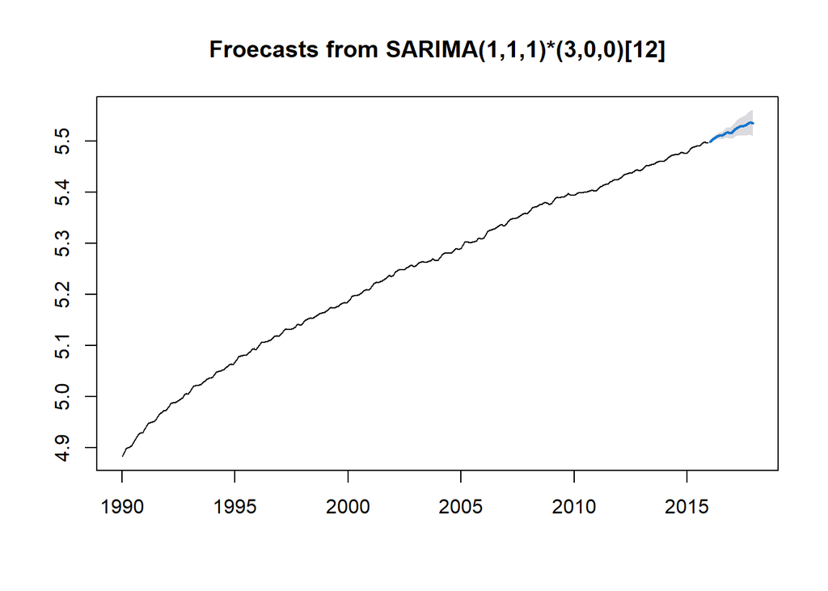

```r
# Fan chart
plot(forcastm121, main = "Froecasts from SARIMA(1,1,1)*(3,0,0)[12]")
```

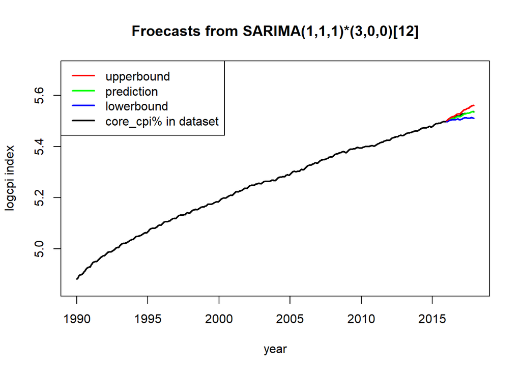

```r
# Fan chart by hand
tscorelogcpi <- ts(corelogcpi$logcpi, start=c(1990,1),end=c(2017,12),frequency=12)
plot(tscorelogcpi, xlab="year", ylab="logcpi index",
     main = "Froecasts from SARIMA(1,1,1)*(3,0,0)[12]",
     lwd = 2, lty = 1, ylim = c(4.85, 5.7))
lines(forcastm121$mean, type = "l", col = "green", lwd = 2)
lines(forcastm121$lower, col = "blue", lwd = 2, lty = 1)
lines(forcastm121$upper, col = "red", lwd = 2, lty = 1)
legend("topleft",
       c("upperbound", "prediction", "lowerbound", "core_cpi% in dataset"),
       lty = 1, lwd = 2,
       col = c("red", "green", "blue", "black"))
```

- 方法二、以時間t作為變數之迴歸處理

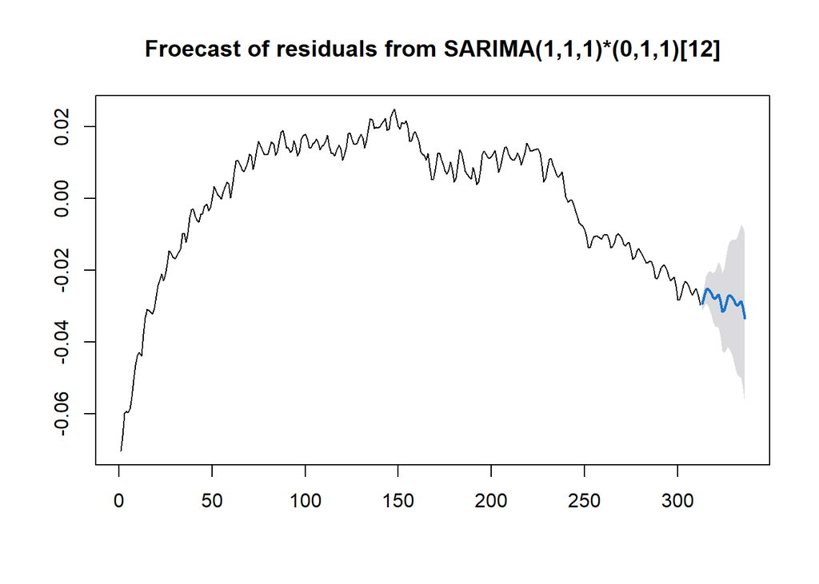

```r
# Fan chart of residuals
plot(forcast42, main = "Froecast of residuals from SARIMA(1,1,1)*(0,1,1)[12]")
```

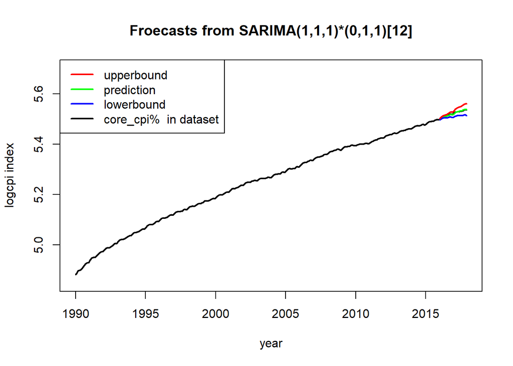

```r
# 從迴歸我們有係數的估計值，將這些係數和所對應測試集的解釋變數相乘並加總，再將這些數值加上預測殘差，結果為測試集的配適值(fitted value)。
beta0_hat <- reg1$coefficients[[1]]
beta1_hat <- reg1$coefficients[[2]]
prederror1 <- forcast42$mean
t <- 313:336
fittedreg1 <- beta0_hat + t*beta1_hat + prederror1
lbd_fit42 <- beta0_hat + t*beta1_hat + forcast42$lower
ubd_fit42 <- beta0_hat + t*beta1_hat + forcast42$upper
fittedreg1 <- ts(fittedreg1, start = c(2016,1), end = c(2017,12), frequency = 12)
lbd_fit42 <- ts(lbd_fit42, start = c(2016,1), end = c(2017,12), frequency = 12)
ubd_fit42 <- ts(ubd_fit42, start = c(2016,1), end = c(2017,12), frequency = 12)
plot(tscorelogcpi, xlab="year", ylab="logcpi index",
     main = "Froecasts from SARIMA(1,1,1)*(0,1,1)[12]",
     lwd = 2, lty = 1, ylim = c(4.85, 5.7))
lines(fittedreg1, type = "l", col = "green", lwd = 2)
lines(lbd_fit42, col = "blue", lwd = 2, lty = 1)
lines(ubd_fit42, col = "red", lwd = 2, lty = 1)
legend("topleft",
       c("upperbound", "prediction", "lowerbound", "core_cpi%  in dataset"),
       lty = 1, lwd = 2,
       col = c("red", "green", "blue", "black"))
```

- 方法三、多變量迴歸處理

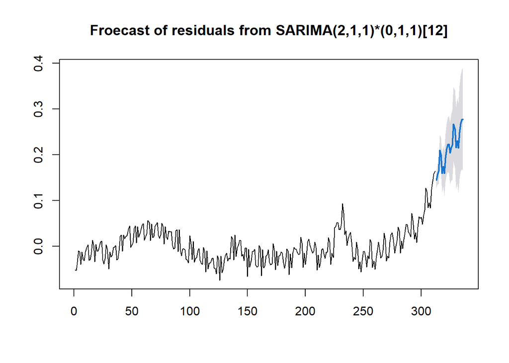

```r
# Fan chart of residuals
plot(forcastm71, main = "Froecast of residuals from SARIMA(2,1,1)*(0,1,1)[12]")
```

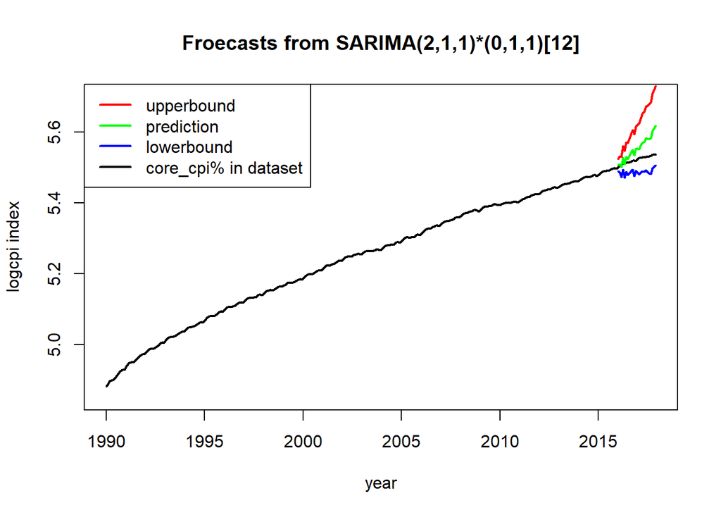

```r
beta0_hat <- reg2$coefficients[[1]]
beta1_hat <- reg2$coefficients[[2]]
beta2_hat <- reg2$coefficients[[3]]
ipi_test <- ipi[313:336, 2]
ue_test <- ue[313:336, 2]
prederror2 <- forcastm71$mean
fittedreg2 <- c()
lbd_fitm71 <- c()
ubd_fitm71 <- c()
for(i in 1:24){

  fittedreg2[i] <- beta0_hat + beta1_hat * ipi_test$IPB50001N[i] + beta2_hat * ue_test$UNRATENSA[i] + prederror2[i]
  lbd_fitm71[i] <- beta0_hat + beta1_hat * ipi_test$IPB50001N[i] + beta2_hat * ue_test$UNRATENSA[i] + forcastm71$lower[i]
  ubd_fitm71[i] <- beta0_hat + beta1_hat * ipi_test$IPB50001N[i] + beta2_hat * ue_test$UNRATENSA[i] + forcastm71$upper[i]

}
fittedreg2 <- ts(fittedreg2, start = c(2016,1), end = c(2017,12), frequency = 12)
lbd_fitm71 <- ts(lbd_fitm71, start = c(2016,1), end = c(2017,12), frequency = 12)
ubd_fitm71 <- ts(ubd_fitm71, start = c(2016,1), end = c(2017,12), frequency = 12)
plot(tscorelogcpi, xlab="year", ylab="logcpi index",
     main = "Froecasts from SARIMA(2,1,1)*(0,1,1)[12]",
     lwd = 2, lty = 1, ylim = c(4.85, 5.7))
lines(fittedreg2, type = "l", col = "green", lwd = 2)
lines(lbd_fitm71, col = "blue", lwd = 2, lty = 1)
lines(ubd_fitm71, col = "red", lwd = 2, lty = 1)
legend("topleft",
       c("upperbound", "prediction", "lowerbound", "core_cpi% in dataset"),
       lty = 1, lwd = 2,
       col = c("red", "green", "blue", "black"))
```

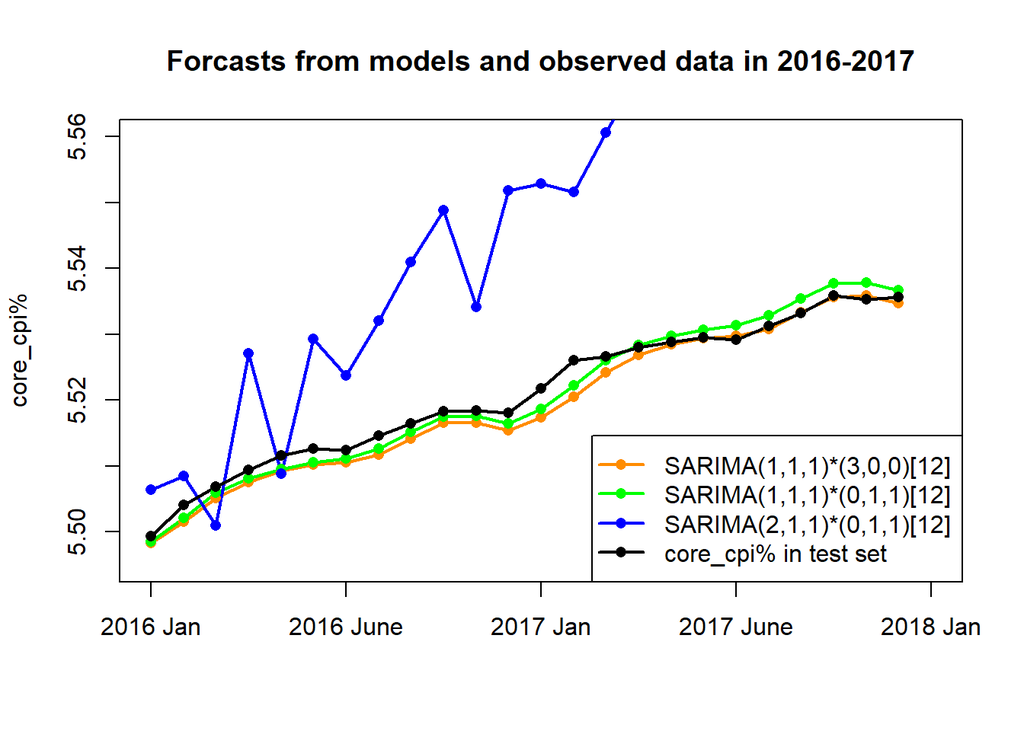

```r
plot(forcastm121$mean,
     ylim = c(5.495, 5.56), xlim = c(2016, 2018), xaxt="n",
     type = "l", col = "darkorange", lwd = 2, xlab = "",
     main = "Forcasts from models and observed data in 2016-2017", ylab = "core_cpi%")
axis(1, at=seq(2016, 2018, by=0.5), labels = c("2016 Jan", "2016 June", "2017 Jan", "2017 June", "2018 Jan"))
lines(fittedreg1, type = "l", col = "green", lwd = 2)
lines(fittedreg2, type = "l", col = "blue", lwd = 2)
observed <- ts(corecpi_test$logcpi, start = c(2016,1), end = c(2017,12), frequency = 12)
lines(observed,type = "l", col = "black", lwd = 2)
points(forcastm121$mean, col = "darkorange", pch = 16)
points(fittedreg1, col = "green", pch = 16)
points(fittedreg2, col = "blue", pch = 16)
points(observed, col = "black", pch = 16)
legend("bottomright",
       c("SARIMA(1,1,1)*(3,0,0)[12]", "SARIMA(1,1,1)*(0,1,1)[12]", "SARIMA(2,1,1)*(0,1,1)[12]", "core_cpi% in test set"),
       lty = 1, lwd = 2,pch = 16,
       col = c("darkorange", "green", "blue", "black"))
```

### 捌、PMSE選模

1. 透過比較PMSE大小選出最佳模型:比較測試集實際和預測的差距
- 方法一、差分處理

```r
pred_corecpi <- data.frame(forcastm121$mean)
error_mfit121 <- c()
errorsq_mfit121 <- c()
for(i in 1:24){

  error_mfit121[i] <- corecpi_test[i,2] - pred_corecpi[i,1]
  errorsq_mfit121[i] <- error_mfit121[i]^2
  PMSE_mfit121 <- mean(errorsq_mfit121)

}
```

- 我們將測試集的實際資料與其配適值相減，計算平方和再取平均，可以得到預測均方差 PMSE。方法二、三的PMSE皆是透過此流程計算得出的結果。
- 方法二、以時間t作為變數之迴歸處理

```r
error_fit42 <- c()
errorsq_fit42 <- c()
for(i in 1:24){

  error_fit42[i] <- corecpi_test[i,2] - fittedreg1[i]
  errorsq_fit42[i] <- error_fit42[i]^2
  PMSE_fit42 <- mean(errorsq_fit42)
}
```

- 方法三、多變量迴歸處理

```r
error_mfit71 <- c()
errorsq_mfit71 <- c()
for(i in 1:24){

  error_mfit71[i] <- corecpi_test[i,2] - fittedreg2[i]
  errorsq_mfit71[i] <- error_mfit71[i]^2
  PMSE_mfit71 <- mean(errorsq_mfit71)

}
```

2. 以表格呈現
- fit42 有最小的 PMSE，其次是 mfit121，最後則是 mfit71。
- 因此 fit42(以時間t為解釋變數的迴歸之配飾模型) 有較良好的預測品質，以此模型作為本次報告通過殘差檢定的最佳配適模型。

```r
result <- round(data.frame(errorsq_mfit121, errorsq_fit42, errorsq_mfit71), 6)
k <- c()
for(i in 1:24){
  k[i] <- paste(i,"-step")
}
rownames(result) <- k
colnames(result) <- c("mfit121", "fit42", "mfit71")

# PMSE
PMSE <- round(c(PMSE_mfit121, PMSE_fit42, PMSE_mfit71), 6)
result <- data.frame(rbind(result, PMSE))
rownames(result)[25] <- "PMSE"
result
```

```
##          mfit121   fit42   mfit71
## 1 -step    1e-06 1.0e-06 0.000049
## 2 -step    6e-06 4.0e-06 0.000019
## 3 -step    3e-06 1.0e-06 0.000034
## 4 -step    3e-06 1.0e-06 0.000315
## 5 -step    5e-06 4.0e-06 0.000008
## 6 -step    6e-06 4.0e-06 0.000277
## 7 -step    3e-06 2.0e-06 0.000129
## 8 -step    8e-06 4.0e-06 0.000304
## 9 -step    5e-06 2.0e-06 0.000607
## 10 -step   3e-06 1.0e-06 0.000928
## 11 -step   3e-06 1.0e-06 0.000249
## 12 -step   7e-06 3.0e-06 0.001145
## 13 -step   2e-05 1.0e-05 0.000969
## 14 -step   3e-05 1.5e-05 0.000653
## 15 -step   6e-06 0.0e+00 0.001160
## 16 -step   1e-06 0.0e+00 0.001721
## 17 -step   0e+00 1.0e-06 0.001935
## 18 -step   0e+00 1.0e-06 0.002748
## 19 -step   0e+00 5.0e-06 0.002471
## 20 -step   0e+00 2.0e-06 0.002380
## 21 -step   0e+00 5.0e-06 0.002404
## 22 -step   0e+00 3.0e-06 0.004448
## 23 -step   0e+00 6.0e-06 0.005507
## 24 -step   1e-06 1.0e-06 0.006646
## PMSE       5e-06 3.0e-06 0.001546
```

### 玖、結論

1. 討論 fit42(SARIMA(1,1,1)*(0,1,1)[12]) 的預測情形：
- 將實際值(observed_data)、配適值(fitted values)、方差(square_error)、預測區間(prediction interval) 以表格呈現。

```r
# 實際值都有在prediction interval內。
data.frame("observed_data" = corecpi_test$logcpi,
           "fitted_value" = fittedreg1,
           "square_error" = round(errorsq_fit42,6),
           "95%_lower_bound" = lbd_fit42,
           "95%_upper_bound" = ubd_fit42
           )
```

```
##    observed_data fitted_value square_error     X95.   X95..1
## 1       5.499330     5.498464      1.0e-06 5.496568 5.500360
## 2       5.504030     5.502056      4.0e-06 5.499215 5.504897
## 3       5.506786     5.505858      1.0e-06 5.502183 5.509532
## 4       5.509356     5.508145      1.0e-06 5.503676 5.512614
## 5       5.511588     5.509520      4.0e-06 5.504273 5.514767
## 6       5.512598     5.510515      4.0e-06 5.504493 5.516537
## 7       5.512396     5.511107      2.0e-06 5.504309 5.517905
## 8       5.514549     5.512617      4.0e-06 5.505037 5.520196
## 9       5.516372     5.515142      2.0e-06 5.506775 5.523509
## 10      5.518328     5.517514      1.0e-06 5.508352 5.526676
## 11      5.518364     5.517579      1.0e-06 5.507613 5.527545
## 12      5.517991     5.516393      3.0e-06 5.505615 5.527170
## 13      5.521793     5.518606      1.0e-05 5.506813 5.530399
## 14      5.526022     5.522209      1.5e-05 5.509390 5.535027
## 15      5.526608     5.526021      0.0e+00 5.512168 5.539874
## 16      5.528007     5.528319      0.0e+00 5.513421 5.543216
## 17      5.528774     5.529704      1.0e-06 5.513753 5.545655
## 18      5.529485     5.530709      1.0e-06 5.513695 5.547724
## 19      5.529175     5.531311      5.0e-06 5.513224 5.549397
## 20      5.531253     5.532830      2.0e-06 5.513664 5.551997
## 21      5.533156     5.535366      5.0e-06 5.515110 5.555621
## 22      5.535908     5.537747      3.0e-06 5.516395 5.559099
## 23      5.535332     5.537821      6.0e-06 5.515365 5.560276
## 24      5.535593     5.536644      1.0e-06 5.513078 5.560209
```

2. 透過計算前後期的差距，可以發現在2016年與2017年底，都有負向的變化量。
- 主要原因是美國聯準會在2015(0.25% –> 0.50%)和2016(0.50% –> 0.75%)年底都有宣布升息。
- 因此選定的最佳配適模型(fit42)有確實反映出升息政策實施後，核心通膨率在未來下降的現象，表示升息政策有抑制通膨的效果，符合本次報告的預期結果。

```r
diff <- c()
for(i in 2:24){
  diff[i] <- round(fittedreg1[i] - fittedreg1[i-1], 6)
}
diff
```

```
##  [1]        NA  0.003592  0.003801  0.002287  0.001375  0.000995  0.000591
##  [8]  0.001510  0.002526  0.002372  0.000065 -0.001186  0.002213  0.003603
## [15]  0.003812  0.002298  0.001385  0.001005  0.000601  0.001520  0.002535
## [22]  0.002381  0.000074 -0.001177
```

### 拾、附錄

- [程式碼及輸出結果](https://chang-web.github.io/Time-Series-Analysis/0609_time-series-final-report.html)
- 資料來源
1. [Core_CPI_Index](https://fred.stlouisfed.org/series/CPILFENS)
2. [Unemployment_rate](https://fred.stlouisfed.org/series/UNRATENSA)
3. [Industrial_Production_Index](https://fred.stlouisfed.org/series/IPB50001N)
- 參考資料
1. [PMSE](http://www.math.chalmers.se/Stat/Grundutb/GU/MSA220/S16/Lecture9-2015.pdf)
2. [What Is the Relationship Between Inflation and Interest Rates?](https://www.investopedia.com/ask/answers/12/inflation-interest-rate-relationship.asp)
3. [Finally! Fed raises interest rates](https://money.cnn.com/2015/12/16/news/economy/federal-reserve-interest-rate-hike/index.html)
4. [History of Federal Open Market Committee actions](https://en.wikipedia.org/wiki/History_of_Federal_Open_Market_Committee_actions#December_2015_historic_interest_rate_hike)